# Genus, diabetes data set

### Data

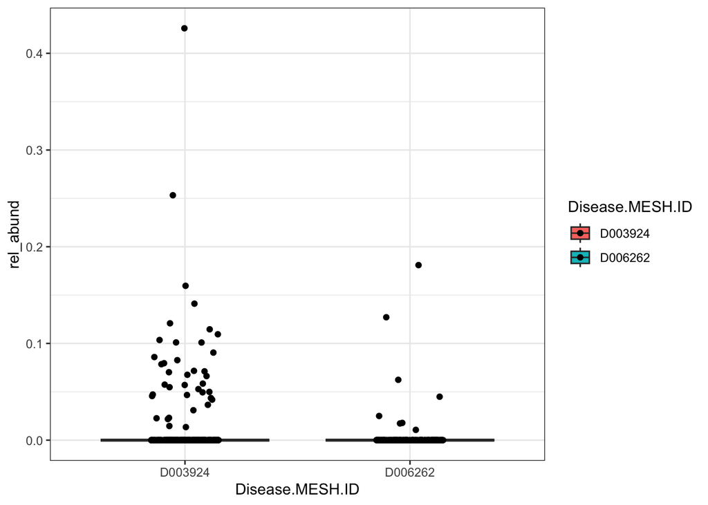

```r
ps_rel <- transform_sample_counts(ps, function(x) x / sum(x))
otu_rel <- as(otu_table(ps_rel), "matrix") %>% t() %>% as.data.frame()
meta_rel <- as(sample_data(ps_rel), "matrix") %>% as.data.frame()
tax_rel <- as(tax_table(ps_rel), "matrix") %>% as.data.frame()
ps_genus <- tax_glom(ps_rel, taxrank = "Genus")

dat_rel <- otu_rel %>%
  rownames_to_column("sample_id") %>%
  pivot_longer(-sample_id, names_to = "taxon", values_to = "rel_abund") %>%
  left_join(meta_rel %>% as("data.frame") %>% rownames_to_column("sample_id"), by = "sample_id") %>%
  left_join(tax_rel %>% rownames_to_column("taxon"), by = "taxon")

one_taxon <- dat_rel$taxon[3]


# Comparison between body sites
dat_rel %>%
  filter(taxon == one_taxon) %>%
  ggplot(aes(x = Disease.MESH.ID, y = rel_abund, fill = Disease.MESH.ID)) +
    geom_boxplot(outlier.shape = NA) +
    geom_jitter(width = 0.15) +
    theme_bw()
```

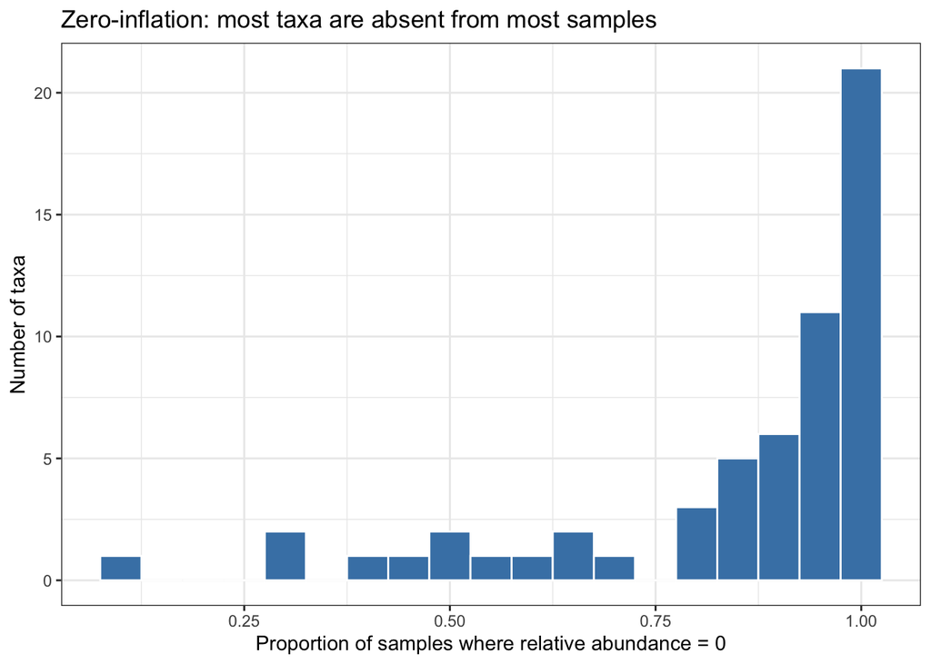

```r
dat_rel %>%
  filter(Disease.MESH.ID == "D003924") %>%
  group_by(taxon) %>%
  summarise(prop_zero = mean(rel_abund == 0), .groups = "drop") %>%
  ggplot(aes(x = prop_zero)) +
    geom_histogram(binwidth = 0.05, fill = "steelblue", color = "white") +
    labs(x = "Proportion of samples where relative abundance = 0",
         y = "Number of taxa",
         title = "Zero-inflation: most taxa are absent from most samples") +
    theme_bw()
```

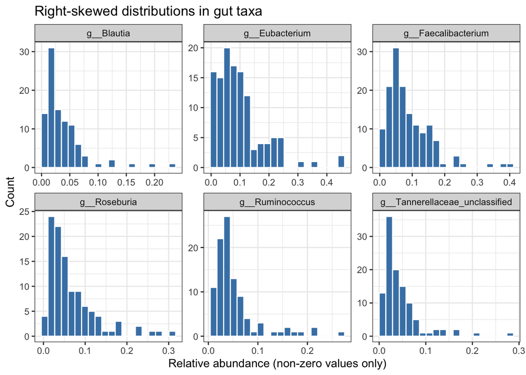

```r
set.seed(42)
example_taxa <- dat_rel %>%
  filter(Disease.MESH.ID == "D006262") %>%
  group_by(taxon, Genus) %>%
  summarise(prop_nonzero = mean(rel_abund > 0), .groups = "drop") %>%
  filter(prop_nonzero > 0.4, prop_nonzero < 0.9) %>%
  slice_sample(n = 6) %>%
  pull(taxon)

dat_rel %>%
  filter(Disease.MESH.ID == "D006262", taxon %in% example_taxa, rel_abund > 0) %>%
  mutate(label = Genus) %>%
  ggplot(aes(x = rel_abund)) +
    geom_histogram(bins = 20, fill = "steelblue", color = "white") +
    facet_wrap(~ label, scales = "free") +
    labs(x = "Relative abundance (non-zero values only)",
         y = "Count",
         title = "Right-skewed distributions in gut taxa") +
    theme_bw()
```

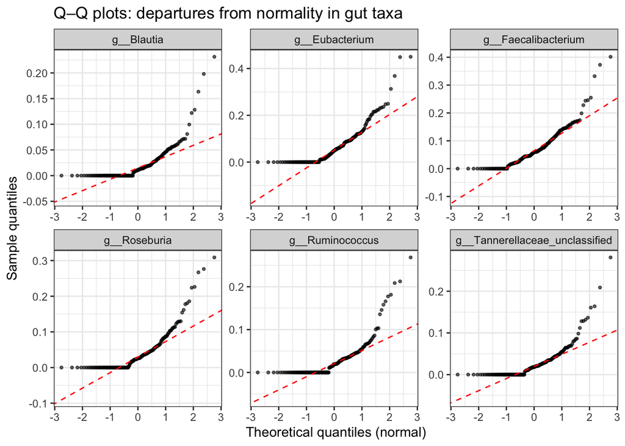

```r
dat_rel %>%
  filter(Disease.MESH.ID == "D006262", taxon %in% example_taxa) %>%
  mutate(label = Genus) %>%
  ggplot(aes(sample = rel_abund)) +
    stat_qq(size = 0.8, alpha = 0.6) +
    stat_qq_line(color = "red", linetype = "dashed") +
    facet_wrap(~ label, scales = "free") +
    labs(x = "Theoretical quantiles (normal)",
         y = "Sample quantiles",
         title = "Q–Q plots: departures from normality in gut taxa") +
    theme_bw()
```

## Helper Functions

```r
# Random subsample of samples from a phyloseq object
sample_ps <- function(ps, FUN = sample, ...) {
  prune_samples(FUN(sample_names(ps), ...), ps)
}

# Alpha-diversity data frame (Shannon + Observed) joined to metadata
make_alpha_df <- function(ps, ps_pa) {
  shannon  <- estimate_richness(ps,    measures = "Shannon")  %>% rownames_to_column("sample_id")
  observed <- estimate_richness(ps_pa, measures = "Observed") %>% rownames_to_column("sample_id")
  meta_df  <- sample_data(ps) %>% data.frame() %>% rownames_to_column("sample_id")

  inner_join(shannon, observed, by = "sample_id") %>%
    inner_join(meta_df, by = "sample_id")
}

# Kruskal-Wallis over multiple grouping variables
run_kruskal <- function(data, response_var, group_vars) {
  map_dfr(group_vars, function(gv) {
    res <- kruskal.test(as.formula(paste(response_var, "~", gv)), data = data)
    data.frame(Variable = gv, Chi_squared = res$statistic,
               df = res$parameter, P_value = res$p.value)
  })
}

# Pairwise Wilcoxon over multiple grouping variables
run_pairwise_wilcoxon <- function(data, response_var, group_vars) {
  map_dfr(group_vars, function(gv) {
    res <- pairwise.wilcox.test(data[[response_var]], data[[gv]],
                                p.adjust.method = "bonferroni")
    as.data.frame(res$p.value) %>%
      rownames_to_column("Group1") %>%
      pivot_longer(-Group1, names_to = "Group2", values_to = "P_value_adj") %>%
      drop_na(P_value_adj) %>%
      mutate(Variable = gv, Comparison = paste(Group1, "vs", Group2)) %>%
      select(Variable, Comparison, P_value_adj, Group1, Group2)
  })
}

# CLR linear model across all taxa, returning results for one term
run_clr_lm <- function(ps_clr, formula_str, term_filter) {
  otu_clr  <- as(otu_table(ps_clr),  "matrix") %>% t() %>% as.data.frame()
  meta_clr <- as(sample_data(ps_clr), "matrix") %>% as.data.frame()
  tax_clr  <- as(tax_table(ps_clr),  "matrix") %>% as.data.frame()

  otu_clr %>%
    rownames_to_column("sample_id") %>%
    pivot_longer(-sample_id, names_to = "taxon", values_to = "clr") %>%
    left_join(meta_clr %>% rownames_to_column("sample_id"), by = "sample_id") %>%
    left_join(tax_clr  %>% rownames_to_column("taxon"),     by = "taxon") %>%
    mutate(
      sex    = factor(Sex,            levels = c("Female", "Male")),
      status = factor(Disease.MESH.ID, levels = c("D006262", "D003924")),
      country= factor(Country,         levels = c("China", "Europe", "United States of America")),
      age    = as.numeric(Host.age),
      bmi    = as.numeric(BMI),
      depth  = as.numeric(Nr..reads.sequenced)
    ) %>%
    group_by(taxon, Phylum, Genus) %>%
    group_modify(~ broom::tidy(lm(as.formula(formula_str), data = .x))) %>%
    filter(term == term_filter) %>%
    ungroup() %>%
    mutate(q_value = p.adjust(p.value, method = "BH"))
}

# Volcano plot from CLR results
plot_volcano <- function(clr_res, x_label, title,
                         pos_label = "Enriched (+)", neg_label = "Enriched (-)") {
  clr_res %>%
    mutate(
      neg_log10_q = -log10(q_value),
      direction   = case_when(
        q_value < 0.05 & estimate > 0 ~ pos_label,
        q_value < 0.05 & estimate < 0 ~ neg_label,
        TRUE ~ "Not significant"
      )
    ) %>%
    ggplot(aes(x = estimate, y = neg_log10_q, color = direction)) +
      geom_point(alpha = 0.6, size = 2) +
      scale_color_manual(values = c(setNames("#E74C3C", pos_label),
                                    setNames("#3498DB", neg_label),
                                    "Not significant" = "grey60")) +
      geom_hline(yintercept = -log10(0.05), linetype = "dashed", color = "grey40") +
      geom_vline(xintercept = 0,            linetype = "dashed", color = "grey40") +
      labs(x = x_label, y = "-log10(q-value)", color = NULL, title = title) +
      theme_bw()
}

# Top-taxa bar chart from CLR results
plot_top_taxa <- function(clr_res, n = 10, x_label, title,
                          pos_label = "Enriched (+)", neg_label = "Enriched (-)",
                          pos_color = "#E74C3C", neg_color = "#3498DB") {
  bind_rows(
    clr_res %>% filter(q_value < 0.05) %>% arrange(estimate)  %>% head(n),
    clr_res %>% filter(q_value < 0.05) %>% arrange(-estimate) %>% head(n)
  ) %>%
    distinct() %>%
    mutate(direction = ifelse(estimate > 0, pos_label, neg_label)) %>%
    ggplot(aes(x = reorder(Genus, estimate), y = estimate, fill = direction)) +
      geom_col() +
      coord_flip() +
      scale_fill_manual(values = c(setNames(pos_color, pos_label),
                                   setNames(neg_color, neg_label))) +
      labs(x = NULL, y = x_label, fill = NULL, title = title) +
      theme_bw()
}

# RDA on CLR matrix: fit model, run permutation ANOVA, return rda object + clean matrices
run_rda <- function(ps_clr, formula_str, covariates) {
  otu_clr  <- as(otu_table(ps_clr),   "matrix") %>% t()
  meta_clr <- as(sample_data(ps_clr), "matrix") %>% as.data.frame() %>%
  mutate(
        across(c(Host.age, BMI, Nr..reads.sequenced), as.numeric),
        # Explicitly set factor levels to match run_clr_lm
        Sex             = factor(Sex,             levels = c("Female", "Male")),
        Disease.MESH.ID = factor(Disease.MESH.ID, levels = c("D006262", "D003924")),
        Country         = factor(Country,         levels = c("China", "Europe", "United States of America"))
      )

  na_idx       <- apply(meta_clr[, covariates, drop = FALSE], 1, anyNA)
  clr_clean    <- otu_clr[!na_idx, ]
  meta_clean   <- meta_clr[!na_idx, ]

  cat("Samples removed due to NAs:", sum(na_idx), "\n")
  cat("Samples retained:", nrow(clr_clean), "\n")

  rda_fit <- rda(as.formula(paste("clr_clean ~", formula_str)), data = meta_clean)

  list(rda = rda_fit, clr_mat = clr_clean, meta = meta_clean)
}

# RDA biplot coloured by one variable, shaped by another (both optional)
plot_rda_biplot <- function(rda_obj, meta_df,
                            color_var, shape_var = NULL,
                            color_values, shape_values = NULL,
                            title = "RDA biplot") {
  eig  <- rda_obj$CCA$eig
  pct1 <- round(eig[1] / rda_obj$tot.chi * 100, 1)
  pct2 <- round(eig[2] / rda_obj$tot.chi * 100, 1)
```

```r
  # 1. Extract site scores
  site_scores <- scores(rda_obj, display = "sites") %>%
    as.data.frame() %>%
    rownames_to_column("sample_id") %>%
    left_join(meta_df %>% rownames_to_column("sample_id"), by = "sample_id")

  # 2. Dynamically determine the orientation sign of RDA1 inside the function
  unique_groups <- unique(site_scores[[color_var]])
  group1 <- unique_groups[1]
  rda1_scores_all <- scores(rda_obj, display = "sites")[, "RDA1"]
  rda1_sign <- ifelse(mean(rda1_scores_all[meta_df[[color_var]] == group1], na.rm = TRUE) >= 0, 1, -1)

  # Apply direction alignment to sites
  site_scores <- site_scores %>% mutate(RDA1 = RDA1 * rda1_sign)

  # 3. Extract environmental biplot arrow scores and apply sign alignment
  bp_scores <- scores(rda_obj, display = "bp") %>%
    as.data.frame() %>%
    mutate(RDA1 = RDA1 * rda1_sign) %>%
    rownames_to_column("variable")

  # 4. Safely extract species/genus mappings from the global 'tax' matrix
  # fallback to extracting species scores using vegan's correct 'species' display argument
  top_species_scores <- scores(rda_obj, display = "species") %>%
    as.data.frame() %>%
    mutate(RDA1 = RDA1 * rda1_sign) %>%
    rownames_to_column("taxon") %>%
    # Use the global 'tax' matrix directly to look up Genus names safely
    left_join(tax %>% rownames_to_column("taxon"), by = "taxon") %>%
    head(10) %>% # Take top 10 rows for clean biplot plotting
    mutate(label = Genus) # Use Genus instead of species since this is genus-level analysis

  # Scale coordinates for visualization consistency
  site_range  <- max(abs(c(site_scores$RDA1, site_scores$RDA2)))
  arrow_scale <- site_range * 0.8 / max(sqrt(bp_scores$RDA1^2 + bp_scores$RDA2^2))
  species_scale <- site_range * 0.6 / max(sqrt(top_species_scores$RDA1^2 + top_species_scores$RDA2^2))

  top_species_scores <- top_species_scores %>% mutate(RDA1 = RDA1 * species_scale, RDA2 = RDA2 * species_scale)
  bp_scores   <- bp_scores %>% mutate(RDA1 = RDA1 * arrow_scale, RDA2 = RDA2 * arrow_scale)

  aes_map <- if (!is.null(shape_var)) {
    aes(x = RDA1, y = RDA2,
        color = .data[[color_var]], shape = .data[[shape_var]])
  } else {
    aes(x = RDA1, y = RDA2, color = .data[[color_var]])
  }

  p <- ggplot() +
    geom_point(data = site_scores, mapping = aes_map, size = 3, alpha = 0.85) +
    # Taxa vectors
    geom_segment(data = top_species_scores,
                 aes(x = 0, y = 0, xend = RDA1, yend = RDA2),
                 arrow = arrow(length = unit(0.15, "cm")),
                 color = "grey70", linewidth = 0.5) +
    geom_text(data = top_species_scores,
              aes(x = RDA1 * 1.15, y = RDA2 * 1.15, label = label),
              size = 2.5, color = "grey50", fontface = "italic") +
    # Biplot constraint arrows
    geom_segment(data = bp_scores,
                 aes(x = 0, y = 0, xend = RDA1, yend = RDA2),
                 arrow = arrow(length = unit(0.25, "cm")),
                 color = "black", linewidth = 1) +
    geom_text(data = bp_scores,
              aes(x = RDA1 * 1.15, y = RDA2 * 1.15, label = variable),
              size = 3.5, fontface = "bold") +
    scale_color_manual(values = color_values) +
    labs(x = paste0("RDA1 (", pct1, "% of total variance)"),
         y = paste0("RDA2 (", pct2, "% of total variance)"),
         title = title) +
    theme_bw()

  if (!is.null(shape_var) && !is.null(shape_values)) {
    p <- p + scale_shape_manual(values = shape_values)
  }
  p
}
# Join RDA taxon loadings with CLR univariate estimates and flag agreement
compare_rda_clr <- function(rda_obj, clr_res, tax_df, rda1_sign = 1) {
  # Change display = "genus" to display = "species"
  taxon_scores <- scores(rda_obj, display = "species")[, 1] * rda1_sign

  tibble(taxon = names(taxon_scores), rda1_loading = taxon_scores) %>%
    left_join(tax_df %>% rownames_to_column("taxon"), by = "taxon") %>%
    left_join(
      clr_res %>% select(taxon, Phylum, Genus,
                         clr_estimate = estimate, clr_q = q_value),
      by = "taxon"
    ) %>%
    mutate(
      direction_agreement = sign(rda1_loading) == sign(clr_estimate),
      clr_result = case_when(
        clr_q < 0.05 & direction_agreement  ~ "CLR significant, same direction",
        clr_q < 0.05 & !direction_agreement ~ "CLR significant, opposite direction",
        TRUE                                ~ "CLR not significant"
      )
    ) %>%
    arrange(desc(abs(rda1_loading)))
}

# Wilcoxon rank-sum test per taxon on relative abundances.
# group_var: the column to split on (e.g. "Disease.MESH.ID" or "Country")
# pos_level: the level treated as the numerator in log2FC (e.g. "D003924" or "Europe")
# neg_level: the denominator level (e.g. "D006262" or "China")
run_wilcoxon <- function(ps_rel, group_var, pos_level, neg_level) {
  otu_rel  <- as(otu_table(ps_rel),   "matrix") %>% t() %>% as.data.frame()
  meta_rel <- as(sample_data(ps_rel), "matrix") %>% as.data.frame()
  tax_rel  <- as(tax_table(ps_rel),   "matrix") %>% as.data.frame()

  otu_rel %>%
    rownames_to_column("sample_id") %>%
    pivot_longer(-sample_id, names_to = "taxon", values_to = "rel_abund") %>%
    left_join(meta_rel %>% rownames_to_column("sample_id"), by = "sample_id") %>%
    left_join(tax_rel  %>% rownames_to_column("taxon"),     by = "taxon") %>%
    group_by(taxon, Genus) %>%
    summarise(
      p_value  = wilcox.test(rel_abund ~ .data[[group_var]], exact = FALSE)$p.value,
      mean_pos = mean(rel_abund[.data[[group_var]] == pos_level], na.rm = TRUE),
      mean_neg = mean(rel_abund[.data[[group_var]] == neg_level], na.rm = TRUE),
      log2_fc  = log2((mean_pos + 1e-6) / (mean_neg + 1e-6)),
      .groups  = "drop"
    ) %>%
    mutate(q_value = p.adjust(p_value, method = "BH"))
}

# Scatter plot: Wilcoxon log2FC vs CLR estimate, coloured by significance category
# Follows the cross-method comparison in differential_abundance.Rmd
plot_wilcox_clr_comparison <- function(wilcox_res, clr_res,
                                       wilcox_x_label, clr_y_label, title) {
  wilcox_res %>%
    select(taxon, wilcox_log2fc = log2_fc, wilcox_q = q_value) %>%
    left_join(
      clr_res %>% select(taxon, clr_estimate = estimate, clr_q = q_value),
      by = "taxon"
    ) %>%
    mutate(
      sig_category = case_when(
        wilcox_q < 0.05 & clr_q < 0.05 ~ "Both significant",
        wilcox_q < 0.05                 ~ "Wilcoxon only",
        clr_q    < 0.05                 ~ "CLR only",
        TRUE                            ~ "Not significant"
      )
    ) %>%
    ggplot(aes(x = wilcox_log2fc, y = clr_estimate, color = sig_category)) +
      geom_point(alpha = 0.6, size = 2) +
      scale_color_manual(values = c(
        "Both significant" = "#E74C3C",
        "Wilcoxon only"    = "#E67E22",
        "CLR only"         = "#3498DB",
        "Not significant"  = "grey70"
      )) +
      geom_hline(yintercept = 0, linetype = "dashed", color = "grey40") +
      geom_vline(xintercept = 0, linetype = "dashed", color = "grey40") +
      labs(x = wilcox_x_label, y = clr_y_label, color = NULL, title = title) +
      theme_bw()
}
```

```r
# Scatter plot: RDA1 loading vs CLR estimate, coloured by agreement
plot_rda_clr_comparison <- function(comparison_df, x_label, y_label, title) {
  comparison_df %>%
    ggplot(aes(x = clr_estimate, y = rda1_loading, color = clr_result)) +
      geom_hline(yintercept = 0, linetype = "dashed", color = "grey40") +
      geom_vline(xintercept = 0, linetype = "dashed", color = "grey40") +
      geom_point(alpha = 0.65, size = 2) +
      scale_color_manual(values = c(
        "CLR significant, same direction"      = "#2E8B57",
        "CLR significant, opposite direction"  = "#E67E22",
        "CLR not significant"                  = "grey70"
      )) +
      labs(x = x_label, y = y_label, color = NULL, title = title) +
      theme_bw()
}
```

# Analysis 1: Global — Diabetics vs. Non-Diabetics (Whole Dataset)

**Question:** Is there a difference in the gut microbiome between diabetics (D003924) and non-diabetics (D006262) across all countries?

## Visualisation

### Barplot (relative abundance, n = 50 sample)

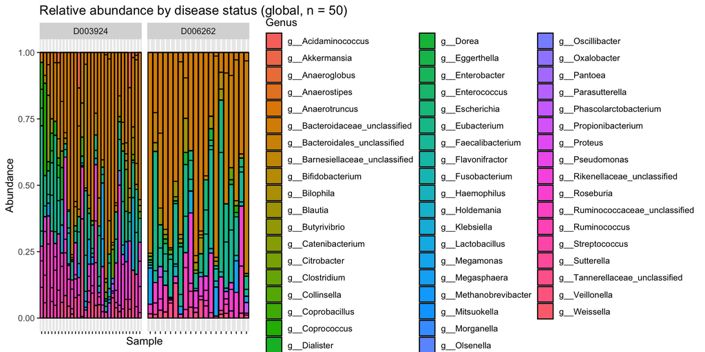

```r
ps_genus_global <- tax_glom(global_t$rel, taxrank = "Genus")
ps_genus_sampled <- sample_ps(ps_genus_global, size = 50)

plot_bar(ps_genus_sampled, fill = "Genus") +
  facet_nested(~ Disease.MESH.ID, scales = "free_x") +
  labs(title = "Relative abundance by disease status (global, n = 50)") +
  theme(axis.text.x = element_blank())
```

### Heat map

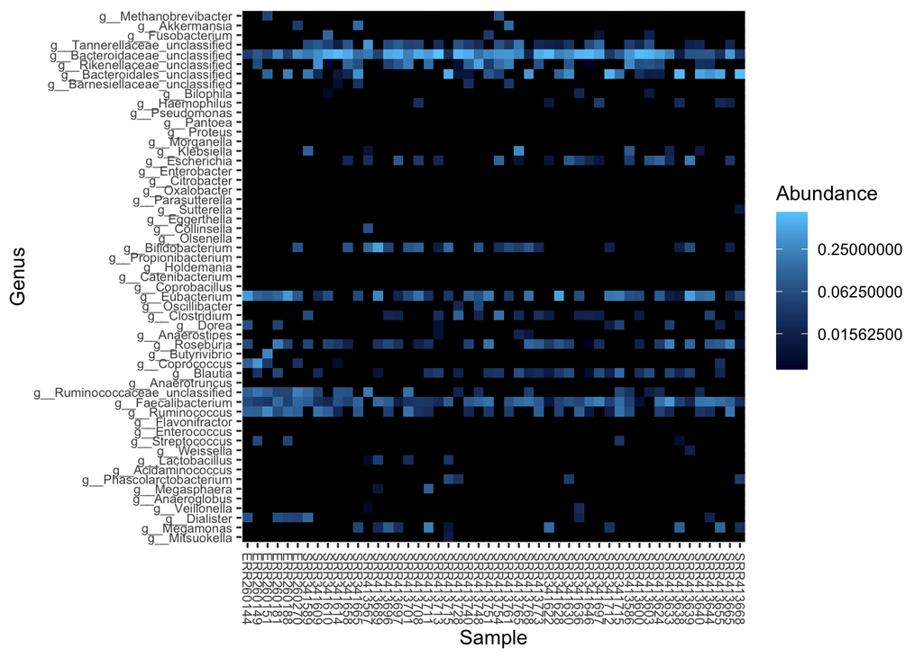

```r
plot_heatmap(ps_genus_sampled, taxa.label = "Genus", sample.order = 'Disease.MESH.ID')
```

## Alpha Diversity

```r
alpha_global <- make_alpha_df(ps_global, global_t$pa)
```

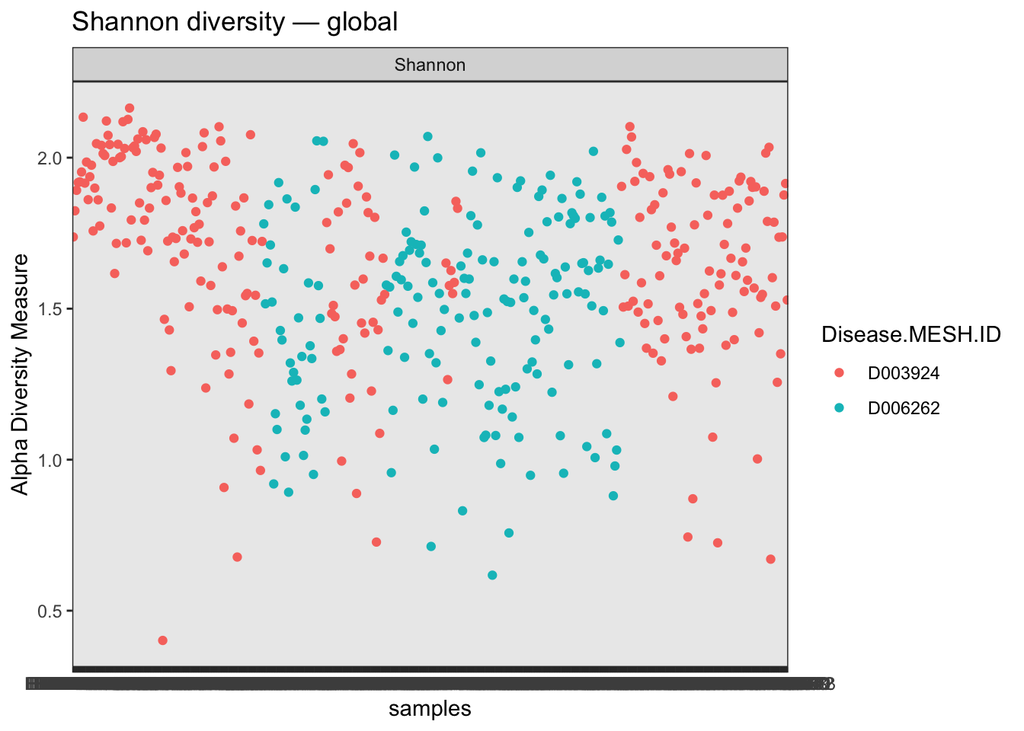

```r
plot_richness(ps_global, measures = "Shannon", color = "Disease.MESH.ID") +
  labs(title = "Shannon diversity — global") +
  theme_bw()
```

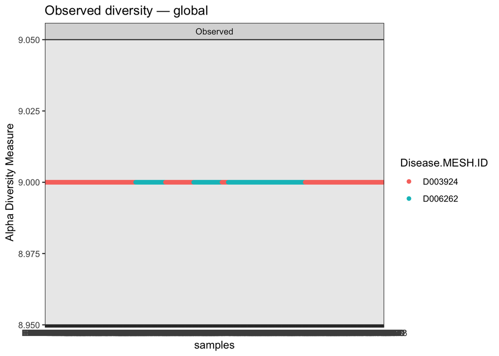

```r
plot_richness(global_t$pa, measures = "Observed", color = "Disease.MESH.ID") +
  labs(title = "Observed diversity — global") +
  theme_bw()
```

```r
run_kruskal(alpha_global, "Shannon", c("Disease.MESH.ID", "Country"))
```

```
##                                       Variable Chi_squared df      P_value
## Kruskal-Wallis chi-squared...1 Disease.MESH.ID    39.33518  1 3.569510e-10
## Kruskal-Wallis chi-squared...2         Country    95.37705  2 1.945976e-21
```

```r
run_pairwise_wilcoxon(alpha_global, "Shannon", c("Disease.MESH.ID","Country"))
```

```
## # A tibble: 4 × 5
##   Variable        Comparison                         P_value_adj Group1   Group2
##   <chr>           <chr>                                    <dbl> <chr>    <chr>
## 1 Disease.MESH.ID D006262 vs D003924                    3.58e-10 D006262  D0039…
## 2 Country         Europe vs China                       1.34e-19 Europe   China
## 3 Country         United States of America vs China     2.42e- 4 United … China
## 4 Country         United States of America vs Europe    7.81e- 3 United … Europe
```

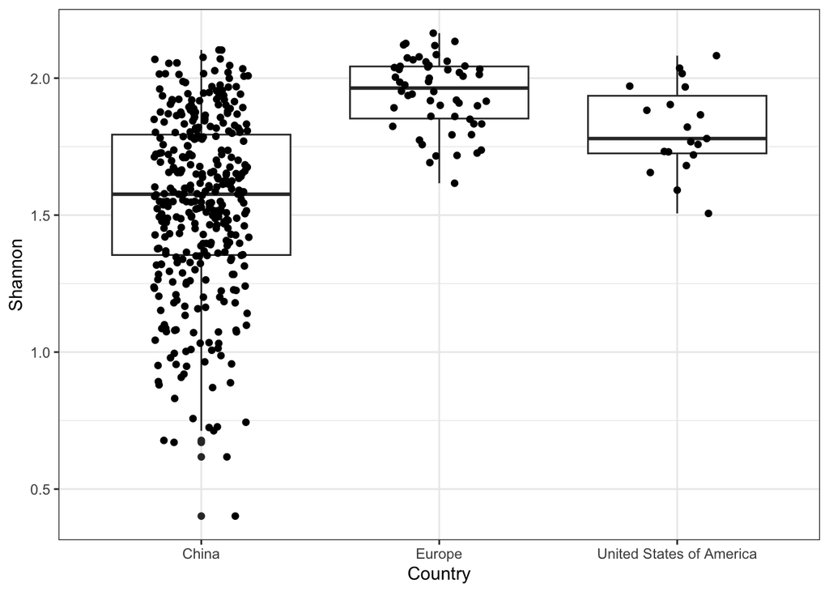

```r
ggplot(alpha_global, aes(x = Country, y = Shannon)) +
  geom_boxplot() +
  geom_jitter(width = 0.2) +
  theme_bw()
```

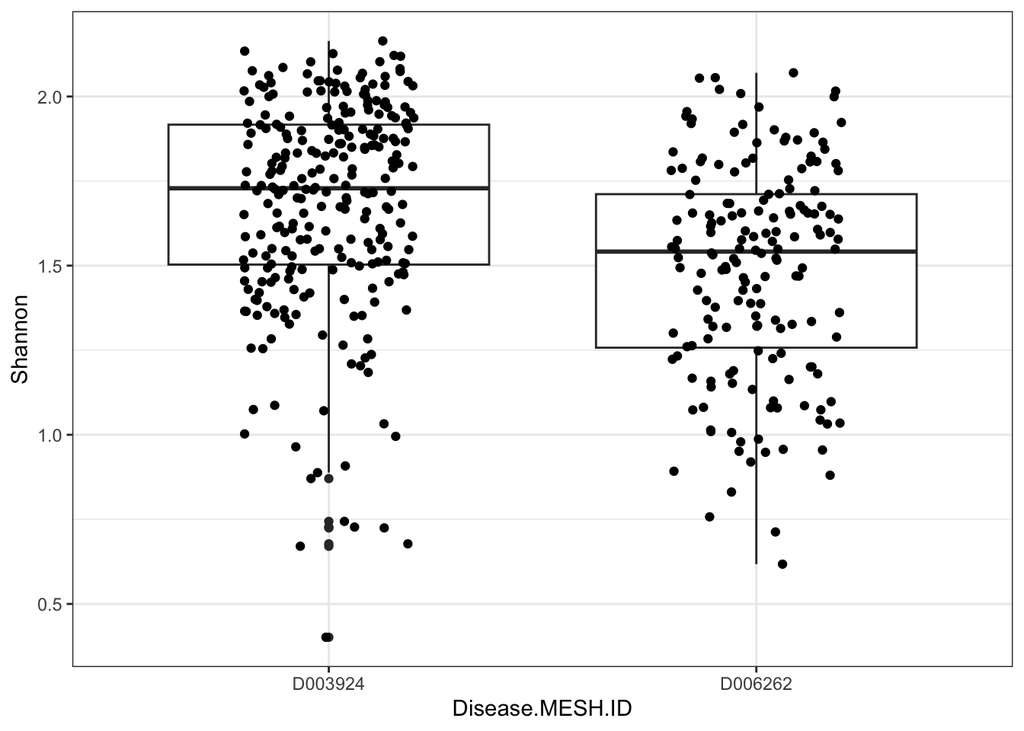

```r
ggplot(alpha_global, aes(x = Disease.MESH.ID, y = Shannon)) +
  geom_boxplot() +
  geom_jitter(width = 0.2) +
  theme_bw()
```

### Sequencing depth vs. Shannon

Negative correlation might be due to the removal of singletons.

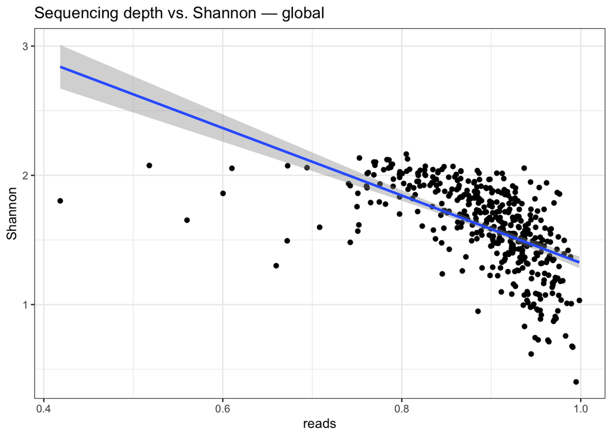

```r
alpha_global$reads <- sample_sums(ps_global)[alpha_global$sample_id]

ggplot(alpha_global, aes(x = reads, y = Shannon)) +
  geom_point() + geom_smooth(method = "lm") +
  labs(title = "Sequencing depth vs. Shannon — global") +
  theme_bw()
```

```r
cor.test(alpha_global$reads, alpha_global$Shannon, method = "spearman")
```

```
##
##  Spearman's rank correlation rho
##
## data:  alpha_global$reads and alpha_global$Shannon
## S = 22985422, p-value < 2.2e-16
## alternative hypothesis: true rho is not equal to 0
## sample estimates:
##       rho
## -0.710625
```

## Beta Diversity

### Calculating the Bray-Curtis distances and the Jaccard distances

```r
bray_dist <- distance(
  ps_global,
  method = "bray"
)

jaccard_dist <- distance(
  global_t$pa,
  method = "jaccard"
)
```

### PCoA — Bray-Curtis

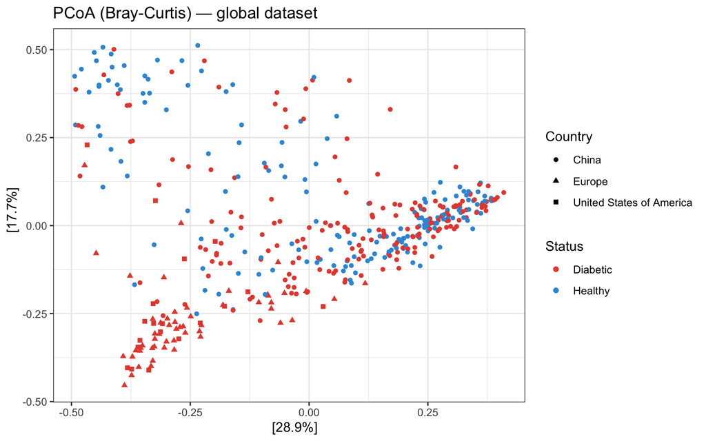

```r
bray_global <- distance(global_t$rel, method = "bray")
ord_global  <- ordinate(global_t$rel, method = "PCoA", distance = bray_global)

plot_ordination(global_t$rel, ord_global, type = "samples",
                color = "Disease.MESH.ID", shape = "Country") +
  scale_color_manual(values = c("D003924" = "#E74C3C", "D006262" = "#3498DB"),
                     labels = c("Diabetic", "Healthy")) +
  labs(title = "PCoA (Bray-Curtis) — global dataset",
       color = "Status") +
  theme_bw()
```

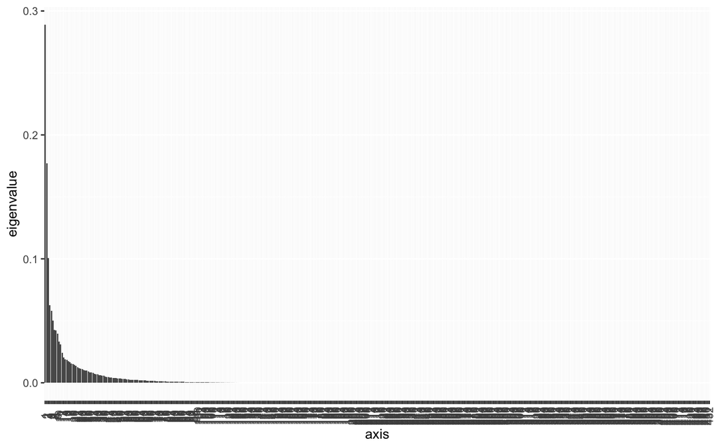

```r
plot_scree(ord_global)
```

### NMDS based on Bray-Curtis distance

NMDS is another commonly used ordination method in ecology and microbiome analysis. Unlike PCoA, it focuses on preserving the rank order of distances rather than the distances themselves.

```r
global_nmds <- ordinate(
  global_t$rel,
  method = "NMDS",
  distance = "bray"
)
```

```
## *** Best solution was not repeated -- monoMDS stopping criteria:
##     15: stress ratio > sratmax
##      5: scale factor of the gradient < sfgrmin
```

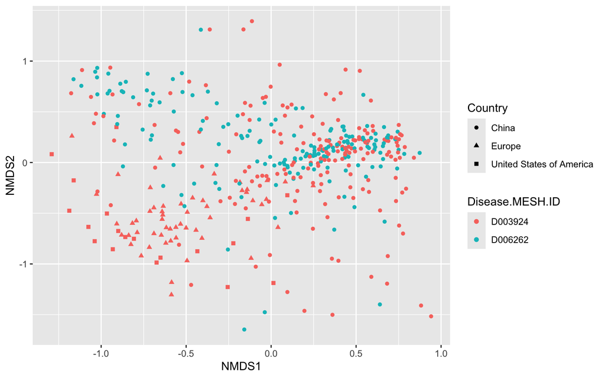

```r
plot_ordination(
  global_t$rel,
  global_nmds,
  type = "samples",
  color = "Disease.MESH.ID",
  shape = "Country"
)
```

### PERMANOVA + Dispersion

```r
sample_df_global <- sample_data(global_t$rel) %>% data.frame()

adonis2(bray_global ~ Disease.MESH.ID,
        data = sample_df_global, permutations = 999)
```

```
## Permutation test for adonis under reduced model
## Permutation: free
## Number of permutations: 999
##
## adonis2(formula = bray_global ~ Disease.MESH.ID, data = sample_df_global, permutations = 999)
##           Df SumOfSqs      R2      F Pr(>F)
## Model      1    2.918 0.02964 13.134  0.001 ***
## Residual 430   95.548 0.97036
## Total    431   98.467 1.00000
## ---
## Signif. codes:  0 '***' 0.001 '**' 0.01 '*' 0.05 '.' 0.1 ' ' 1
```

```r
# Dispersion check
disp_global <- betadisper(bray_global, sample_df_global$Disease.MESH.ID)
anova(disp_global)
```

```
## Analysis of Variance Table
##
## Response: Distances
##            Df Sum Sq Mean Sq F value    Pr(>F)
## Groups      1 0.4219 0.42190  21.815 4.021e-06 ***
## Residuals 430 8.3162 0.01934
## ---
## Signif. codes:  0 '***' 0.001 '**' 0.01 '*' 0.05 '.' 0.1 ' ' 1
```

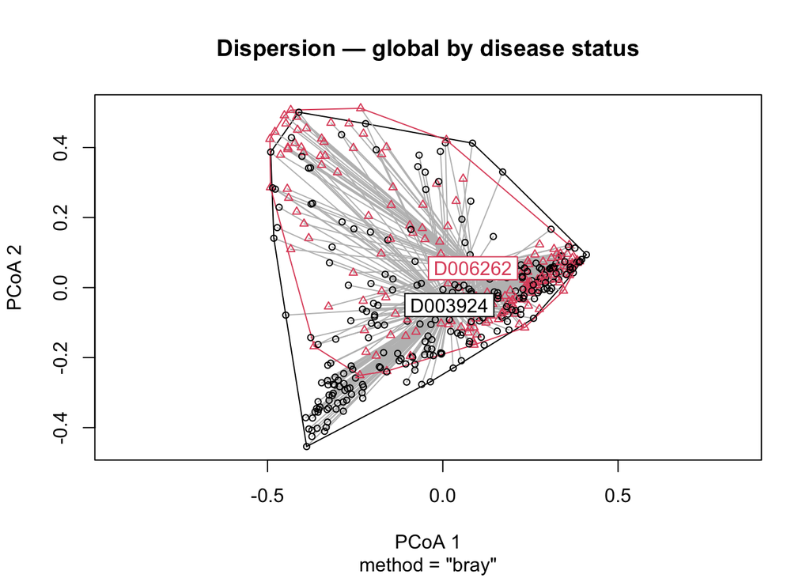

```r
plot(disp_global, main = "Dispersion — global by disease status")
```

## Compositional Analysis — CLR Linear Model

The model adjusts for sex, country, age, and sequencing depth; the term of interest is `statusD003924` (diabetic relative to healthy).

### Running CLR

```r
clr_global <- run_clr_lm(
  ps_clr       = global_t$clr,
  formula_str  = "clr ~ sex + country + status + age + depth",
  term_filter  = "statusD003924"
)


global_healthy_enriched <- clr_global %>%
  select(taxon, Genus, estimate, std.error, statistic, p.value, q_value) %>%
  arrange(estimate) %>%
  head(10)

global_sick_enriched <- clr_global %>%
  select(taxon, Genus, estimate, std.error, statistic, p.value, q_value) %>%
  arrange(-estimate) %>%
  head(10)

global_healthy_enriched
```

```
## # A tibble: 10 × 7
##    taxon  Genus                     estimate std.error statistic p.value q_value
##    <chr>  <chr>                        <dbl>     <dbl>     <dbl>   <dbl>   <dbl>
##  1 841    g__Roseburia                -4.02      0.989    -4.06  5.91e-5 0.00343
##  2 216851 g__Faecalibacterium         -2.99      0.881    -3.39  7.71e-4 0.0149
##  3 838    g__Bacteroidales_unclass…   -2.27      0.967    -2.34  1.96e-2 0.114
##  4 1730   g__Eubacterium              -1.82      0.934    -1.94  5.26e-2 0.218
##  5 724    g__Haemophilus              -1.25      0.488    -2.57  1.04e-2 0.101
##  6 33042  g__Coprococcus              -0.941     0.671    -1.40  1.61e-1 0.520
##  7 570    g__Klebsiella               -0.823     0.656    -1.26  2.10e-1 0.580
##  8 1263   g__Ruminococcus             -0.703     0.980    -0.717 4.74e-1 0.916
##  9 572511 g__Blautia                  -0.611     1.00     -0.610 5.42e-1 0.983
## 10 544    g__Citrobacter              -0.368     0.186    -1.98  4.83e-2 0.215
```

```r
global_sick_enriched
```

```
## # A tibble: 10 × 7
##    taxon  Genus                     estimate std.error statistic p.value q_value
##    <chr>  <chr>                        <dbl>     <dbl>     <dbl>   <dbl>   <dbl>
##  1 375288 g__Tannerellaceae_unclas…    2.59      0.884     2.93  3.57e-3  0.0518
##  2 906    g__Megasphaera               2.16      0.615     3.52  4.84e-4  0.0140
##  3 1578   g__Lactobacillus             1.41      0.517     2.74  6.49e-3  0.0753
##  4 1678   g__Bifidobacterium           1.38      0.948     1.45  1.46e-1  0.500
##  5 239934 g__Akkermansia               1.30      0.606     2.15  3.20e-2  0.169
##  6 397864 g__Barnesiellaceae_uncla…    1.16      0.494     2.35  1.94e-2  0.114
##  7 100883 g__Coprobacillus             1.00      0.401     2.50  1.28e-2  0.106
##  8 292632 g__Ruminococcaceae_uncla…    0.776     0.952     0.815 4.15e-1  0.855
##  9 848    g__Fusobacterium             0.706     0.559     1.26  2.07e-1  0.580
## 10 904    g__Acidaminococcus           0.704     0.368     1.91  5.64e-2  0.218
```

### Plots

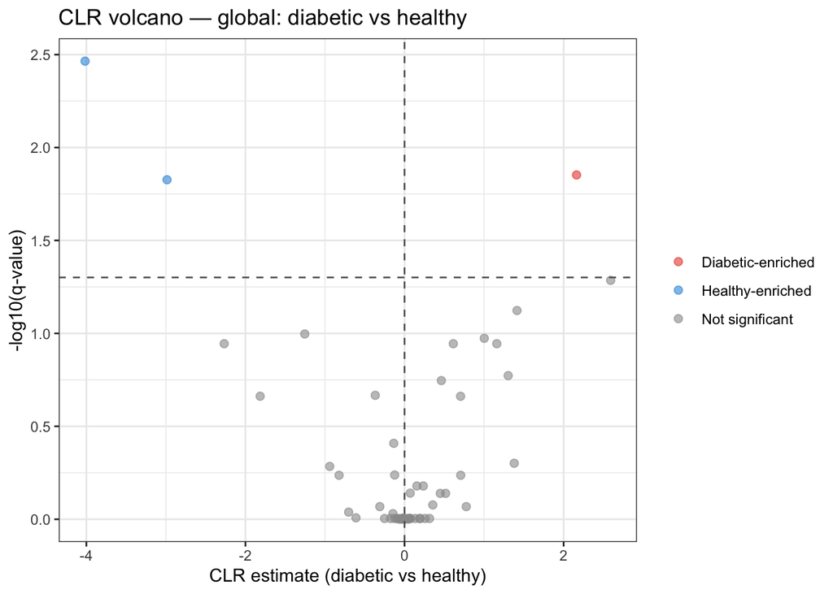

```r
plot_volcano(clr_global,
             x_label   = "CLR estimate (diabetic vs healthy)",
             title     = "CLR volcano — global: diabetic vs healthy",
             pos_label = "Diabetic-enriched",
             neg_label = "Healthy-enriched")
```

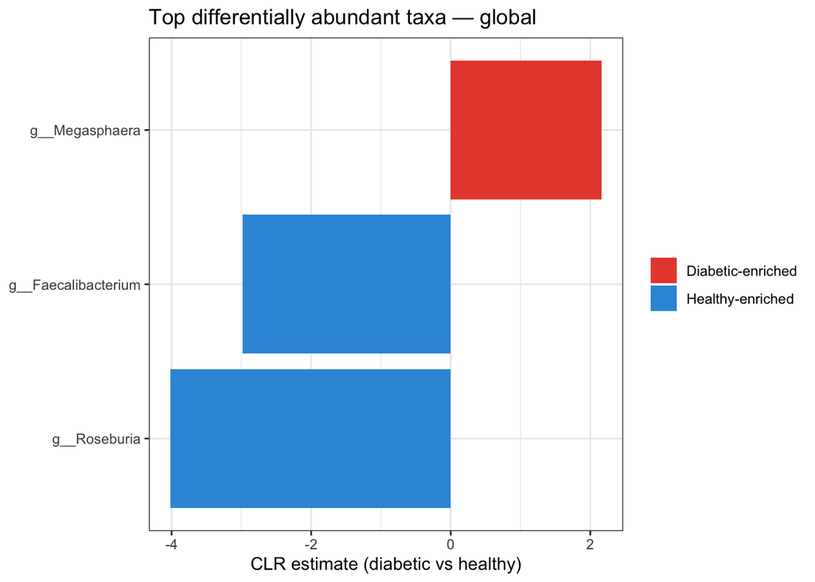

```r
plot_top_taxa(clr_global,
              x_label   = "CLR estimate (diabetic vs healthy)",
              title     = "Top differentially abundant taxa — global",
              pos_label = "Diabetic-enriched",
              neg_label = "Healthy-enriched")
```

## Constrained Ordination — RDA

The CLR matrix is constrained by disease status, country, sex, age, and sequencing depth. This tests which predictors explain significant variation in the full community composition simultaneously.

```r
rda_global_out <- run_rda(
  ps_clr      = global_t$clr,
  formula_str = "Disease.MESH.ID + Country + Sex + as.numeric(Host.age) + as.numeric(Nr..reads.sequenced)",
  covariates  = c("Disease.MESH.ID", "Country", "Sex", "Host.age", "Nr..reads.sequenced")
)
```

```
## Samples removed due to NAs: 19
## Samples retained: 413
```

```r
# Permutation ANOVA — overall model and per-term
anova(rda_global_out$rda, permutations = 999)
```

```
## Permutation test for rda under reduced model
## Permutation: free
## Number of permutations: 999
##
## Model: rda(formula = clr_clean ~ Disease.MESH.ID + Country + Sex + as.numeric(Host.age) + as.numeric(Nr..reads.sequenced), data = meta_clean)
##           Df Variance      F Pr(>F)
## Model      5   105.32 6.3284  0.001 ***
## Residual 407  1354.75
## ---
## Signif. codes:  0 '***' 0.001 '**' 0.01 '*' 0.05 '.' 0.1 ' ' 1
```

```r
anova(rda_global_out$rda, by = "term", permutations = 999)
```

```
## Permutation test for rda under reduced model
## Terms added sequentially (first to last)
## Permutation: free
## Number of permutations: 999
##
## Model: rda(formula = clr_clean ~ Disease.MESH.ID + Country + Sex + as.numeric(Host.age) + as.numeric(Nr..reads.sequenced), data = meta_clean)
##                                  Df Variance       F Pr(>F)
## Disease.MESH.ID                   1    18.88  5.6708  0.001 ***
## Country                           1    73.68 22.1364  0.001 ***
## Sex                               1     4.33  1.3022  0.168
## as.numeric(Host.age)              1     4.77  1.4327  0.096 .
## as.numeric(Nr..reads.sequenced)   1     3.66  1.1000  0.325
## Residual                        407  1354.75
## ---
## Signif. codes:  0 '***' 0.001 '**' 0.01 '*' 0.05 '.' 0.1 ' ' 1
```

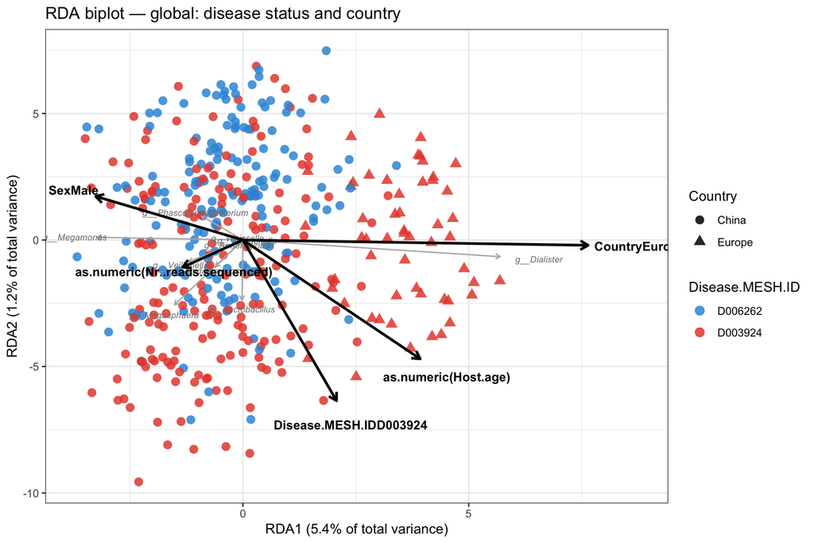

```r
plot_rda_biplot(
  rda_obj      = rda_global_out$rda,
  meta_df      = rda_global_out$meta,
  color_var    = "Disease.MESH.ID",
  shape_var    = "Country",
  color_values = c("D003924" = "#E74C3C", "D006262" = "#3498DB"),
  shape_values = c("China" = 16, "Europe" = 17),
  title        = "RDA biplot — global: disease status and country"
)
```

### RDA vs CLR comparison

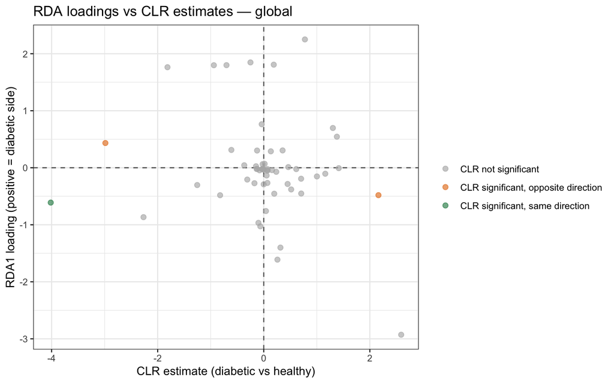

```r
# Sign of RDA1 is arbitrary; orient so that the diabetic group has positive RDA1
rda1_scores_global <- scores(rda_global_out$rda, display = "sites")[, "RDA1"]
rda1_sign_global <- ifelse(
  mean(rda1_scores_global[rda_global_out$meta$Disease.MESH.ID == "D003924"], na.rm = TRUE) >=
  mean(rda1_scores_global[rda_global_out$meta$Disease.MESH.ID == "D006262"], na.rm = TRUE),
  1, -1
)

comp_global <- compare_rda_clr(
  rda_obj  = rda_global_out$rda,
  clr_res  = clr_global,
  tax_df   = as(tax_table(global_t$clr), "matrix") %>% as.data.frame(),
  rda1_sign = rda1_sign_global
)

plot_rda_clr_comparison(
  comp_global,
  x_label = "CLR estimate (diabetic vs healthy)",
  y_label = "RDA1 loading (positive = diabetic side)",
  title   = "RDA loadings vs CLR estimates — global"
)
```

```r
comp_global %>%
  arrange(desc(abs(rda1_loading))) %>%
  select(Phylum.x, Genus.x, rda1_loading, clr_estimate, clr_q, direction_agreement) %>%
  head(20)
```

```
## # A tibble: 20 × 6
##    Phylum.x        Genus.x rda1_loading clr_estimate   clr_q direction_agreement
##    <chr>           <chr>          <dbl>        <dbl>   <dbl> <lgl>
##  1 p__Bacteroidota g__Tan…       -2.93        2.59   0.0518  FALSE
##  2 p__Bacillota    g__Rum…        2.25        0.776  0.855   TRUE
##  3 p__Bacillota    g__Dor…        1.85       -0.251  0.991   FALSE
##  4 p__Bacillota    g__Dia…        1.81        0.189  0.991   TRUE
##  5 p__Bacillota    g__Rum…        1.80       -0.703  0.916   FALSE
##  6 p__Bacillota    g__Cop…        1.80       -0.941  0.520   FALSE
##  7 p__Bacillota    g__Eub…        1.76       -1.82   0.218   FALSE
##  8 p__Bacteroidota g__Rik…       -1.61        0.258  0.991   FALSE
##  9 p__Pseudomonad… g__Esc…       -1.40        0.314  0.991   FALSE
## 10 p__Bacillota    g__Meg…       -1.03       -0.0651 0.999   TRUE
## 11 p__Bacteroidota g__Bac…       -0.967      -0.101  0.991   TRUE
## 12 p__Bacteroidota g__Bac…       -0.866      -2.27   0.114   TRUE
## 13 p__Bacillota    g__Str…        0.763      -0.0387 0.999   FALSE
## 14 p__Bacillota    g__Clo…       -0.759       0.0413 0.999   FALSE
## 15 p__Verrucomicr… g__Akk…        0.697       1.30   0.169   TRUE
## 16 p__Bacillota    g__Ros…       -0.611      -4.02   0.00343 TRUE
## 17 p__Actinomycet… g__Bif…        0.545       1.38   0.500   TRUE
## 18 p__Pseudomonad… g__Kle…       -0.482      -0.823  0.580   TRUE
## 19 p__Bacillota    g__Meg…       -0.481       2.16   0.0140  FALSE
## 20 p__Desulfobact… g__Bil…       -0.455       0.198  0.991   FALSE
```

# Analysis 2: China — Diabetics vs. Non-Diabetics

**Question:** Within China, is there a difference in the gut microbiome between diabetics and non-diabetics?

## Visualisation

### Barplot (relative abundance, n = 50 sample)

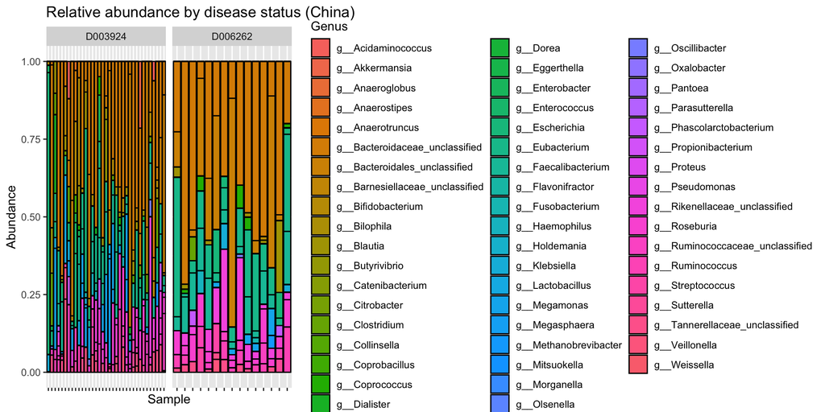

```r
ps_genus_china  <- tax_glom(china_t$rel, taxrank = "Genus")
china_genus_sampled <- sample_ps(ps_genus_china, size = min(50, nsamples(ps_genus_china)))

plot_bar(china_genus_sampled, fill = "Genus") +
  facet_nested(~ Disease.MESH.ID, scales = "free_x") +
  labs(title = "Relative abundance by disease status (China)") +
  theme(axis.text.x = element_blank())
```

## Alpha Diversity

```r
alpha_china <- make_alpha_df(ps_china, china_t$pa)
```

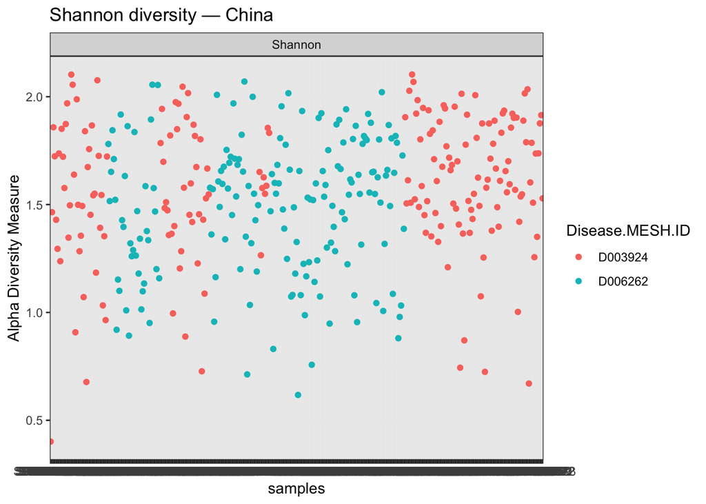

```r
plot_richness(ps_china, measures = "Shannon", color = "Disease.MESH.ID") +
  labs(title = "Shannon diversity — China") +
  theme_bw()
```

```r
run_kruskal(alpha_china, "Shannon", "Disease.MESH.ID")
```

```
##                                   Variable Chi_squared df     P_value
## Kruskal-Wallis chi-squared Disease.MESH.ID    9.716706  1 0.001826005
```

```r
run_pairwise_wilcoxon(alpha_china, "Shannon", "Disease.MESH.ID")
```

```
## # A tibble: 1 × 5
##   Variable        Comparison         P_value_adj Group1  Group2
##   <chr>           <chr>                    <dbl> <chr>   <chr>
## 1 Disease.MESH.ID D006262 vs D003924     0.00183 D006262 D003924
```

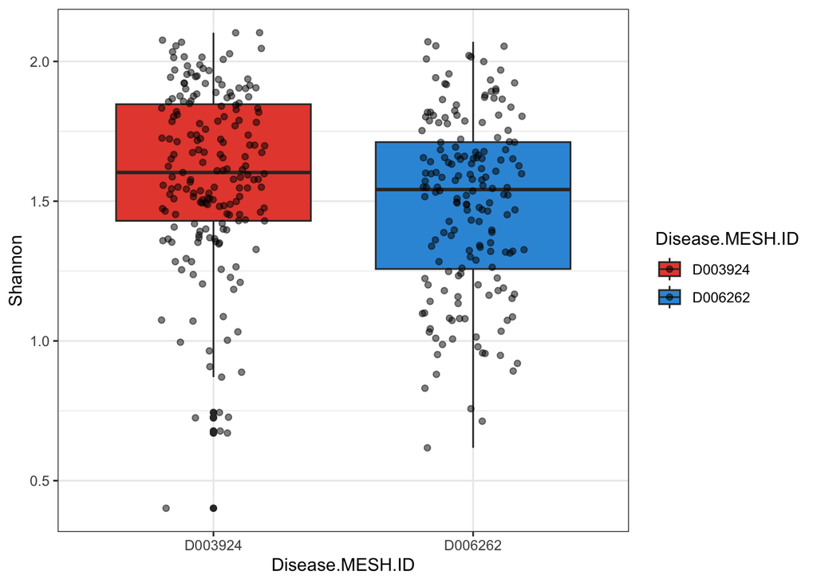

```r
ggplot(alpha_china, aes(x = Disease.MESH.ID, y = Shannon, fill = Disease.MESH.ID)) +
  geom_boxplot() +
  geom_jitter(width = 0.2, alpha = 0.5) +
  theme_bw() +
  scale_fill_manual(values = c("#E74C3C", "#3498DB"))
```

### Sequencing depth vs. Shannon

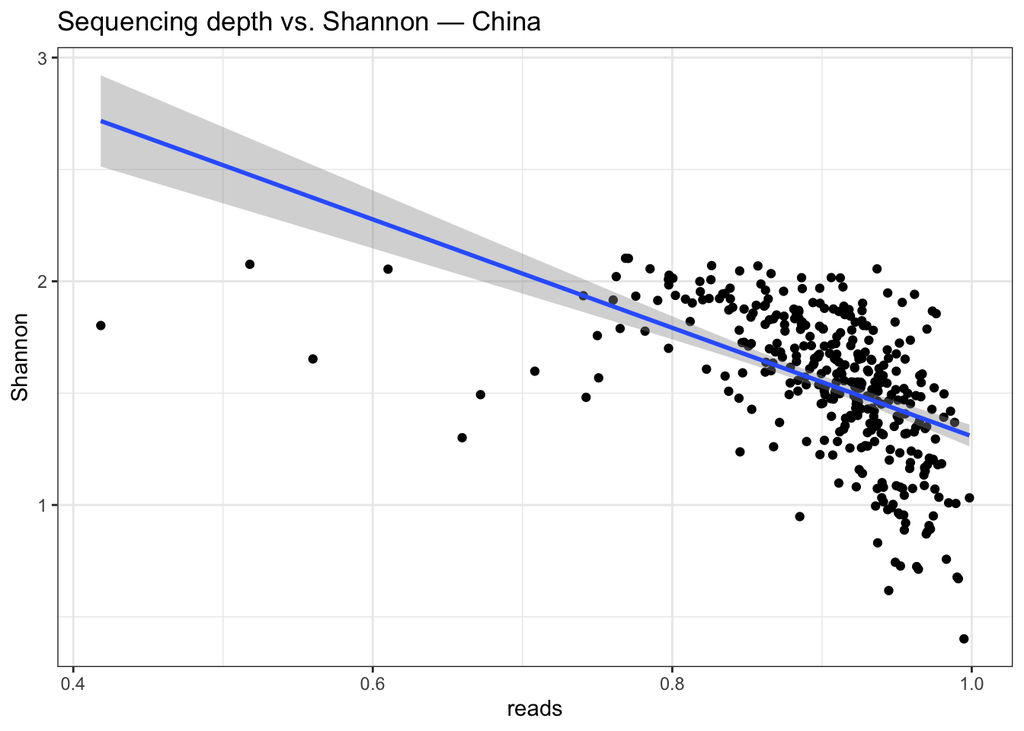

```r
alpha_china$reads <- sample_sums(ps_china)[alpha_china$sample_id]

ggplot(alpha_china, aes(x = reads, y = Shannon)) +
  geom_point() + geom_smooth(method = "lm") +
  labs(title = "Sequencing depth vs. Shannon — China") +
  theme_bw()
```

```r
cor.test(alpha_china$reads, alpha_china$Shannon, method = "spearman")
```

```
##
##  Spearman's rank correlation rho
##
## data:  alpha_china$reads and alpha_china$Shannon
## S = 12765296, p-value < 2.2e-16
## alternative hypothesis: true rho is not equal to 0
## sample estimates:
##       rho
## -0.655397
```

## Beta Diversity — PERMANOVA

### Calculating the Bray-Curtis distances and the Jaccard distances

```r
bray_dist <- distance(
  ps_china,
  method = "bray"
)

jaccard_dist <- distance(
  china_t$pa,
  method = "jaccard"
)
```

### PCoA — Bray-Curtis

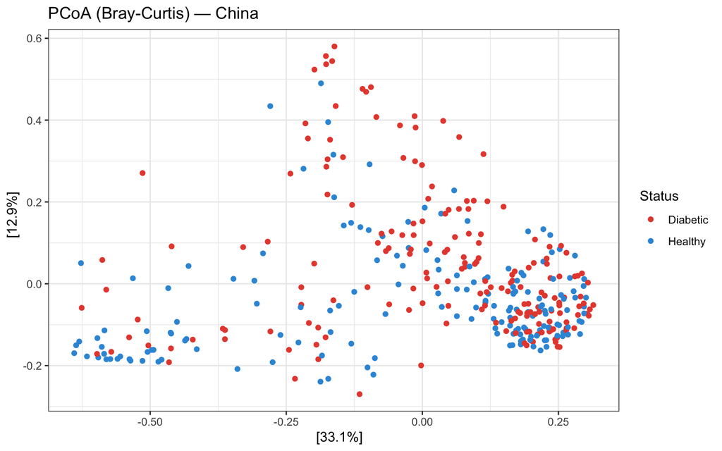

```r
bray_china <- distance(china_t$rel, method = "bray")
ord_china  <- ordinate(china_t$rel, method = "PCoA", distance = bray_china)

plot_ordination(china_t$rel, ord_china, type = "samples",
                color = "Disease.MESH.ID") +
  scale_color_manual(values = c("D003924" = "#E74C3C", "D006262" = "#3498DB"),
                     labels = c("Diabetic", "Healthy")) +
  labs(title = "PCoA (Bray-Curtis) — China",
       color = "Status") +
  theme_bw()
```

### NMDS based on Bray-Curtis distance

NMDS is another commonly used ordination method in ecology and microbiome analysis. Unlike PCoA, it focuses on preserving the rank order of distances rather than the distances themselves.

```r
global_nmds <- ordinate(
  china_t$rel,
  method = "NMDS",
  distance = "bray"
)
```

```
## *** Best solution was not repeated -- monoMDS stopping criteria:
##     16: stress ratio > sratmax
##      4: scale factor of the gradient < sfgrmin
```

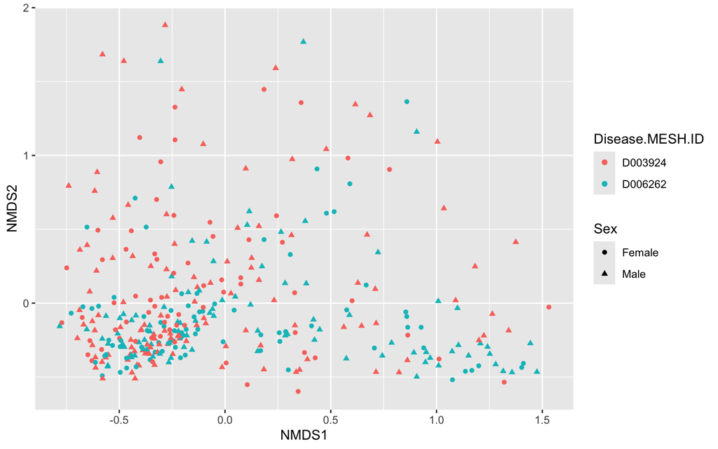

```r
plot_ordination(
  china_t$rel,
  global_nmds,
  type = "samples",
  color = "Disease.MESH.ID",
  shape = "Sex"
)
```

### PERMANOVA + Dispersion

```r
sample_df_china <- sample_data(china_t$rel) %>% data.frame()

adonis2(bray_china ~ Disease.MESH.ID,
        data = sample_df_china, permutations = 999)
```

```
## Permutation test for adonis under reduced model
## Permutation: free
## Number of permutations: 999
##
## adonis2(formula = bray_china ~ Disease.MESH.ID, data = sample_df_china, permutations = 999)
##           Df SumOfSqs      R2      F Pr(>F)
## Model      1    1.358 0.01863 6.7759  0.001 ***
## Residual 357   71.552 0.98137
## Total    358   72.910 1.00000
## ---
## Signif. codes:  0 '***' 0.001 '**' 0.01 '*' 0.05 '.' 0.1 ' ' 1
```

```r
disp_china <- betadisper(bray_china, sample_df_china$Disease.MESH.ID)
anova(disp_china)
```

```
## Analysis of Variance Table
##
## Response: Distances
##            Df Sum Sq  Mean Sq F value Pr(>F)
## Groups      1 0.0338 0.033824  1.4089  0.236
## Residuals 357 8.5709 0.024008
```

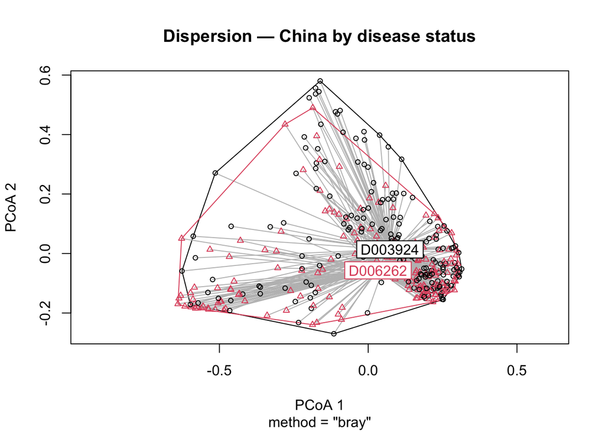

```r
plot(disp_china, main = "Dispersion — China by disease status")
```

## Wilcoxon Rank-Sum Test

One Wilcoxon test per taxon on relative abundances, diabetics vs. healthy within China. `log2_fc` is positive for diabetic-enriched taxa.

```r
wilcox_china <- run_wilcoxon(
  ps_rel    = china_t$rel,
  group_var = "Disease.MESH.ID",
  pos_level = "D003924",   # diabetic = numerator
  neg_level = "D006262"    # healthy  = denominator
)

# Top diabetic-enriched (positive log2FC)
wilcox_china %>%
  filter(q_value < 0.05) %>%
  arrange(-log2_fc) %>%
  select(Genus, mean_pos, mean_neg, log2_fc, p_value, q_value) %>%
  head(10)
```

```
## # A tibble: 8 × 6
##   Genus                          mean_pos mean_neg log2_fc    p_value  q_value
##   <chr>                             <dbl>    <dbl>   <dbl>      <dbl>    <dbl>
## 1 g__Lactobacillus                 0.0123  0.00138   3.16  0.0000354  0.000992
## 2 g__Megasphaera                   0.0148  0.00226   2.72  0.000114   0.00159
## 3 g__Akkermansia                   0.0115  0.00261   2.14  0.00491    0.0344
## 4 g__Bifidobacterium               0.0447  0.0115    1.96  0.00143    0.0133
## 5 g__Tannerellaceae_unclassified   0.0477  0.0288    0.731 0.000746   0.00836
## 6 g__Faecalibacterium              0.0477  0.0728   -0.610 0.0000822  0.00153
## 7 g__Roseburia                     0.0218  0.0425   -0.965 0.00000332 0.000186
## 8 g__Bacteroidales_unclassified    0.0676  0.149    -1.14  0.00222    0.0177
```

```r
# Top healthy-enriched (negative log2FC)
wilcox_china %>%
  filter(q_value < 0.05) %>%
  arrange(log2_fc) %>%
  select(Genus, mean_pos, mean_neg, log2_fc, p_value, q_value) %>%
  head(10)
```

```
## # A tibble: 8 × 6
##   Genus                          mean_pos mean_neg log2_fc    p_value  q_value
##   <chr>                             <dbl>    <dbl>   <dbl>      <dbl>    <dbl>
## 1 g__Bacteroidales_unclassified    0.0676  0.149    -1.14  0.00222    0.0177
## 2 g__Roseburia                     0.0218  0.0425   -0.965 0.00000332 0.000186
## 3 g__Faecalibacterium              0.0477  0.0728   -0.610 0.0000822  0.00153
## 4 g__Tannerellaceae_unclassified   0.0477  0.0288    0.731 0.000746   0.00836
## 5 g__Bifidobacterium               0.0447  0.0115    1.96  0.00143    0.0133
## 6 g__Akkermansia                   0.0115  0.00261   2.14  0.00491    0.0344
## 7 g__Megasphaera                   0.0148  0.00226   2.72  0.000114   0.00159
## 8 g__Lactobacillus                 0.0123  0.00138   3.16  0.0000354  0.000992
```

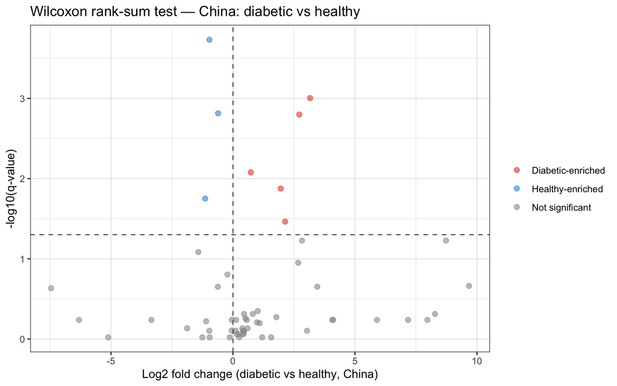

```r
# Volcano plot
wilcox_china %>%
  mutate(
    neg_log10_q = -log10(q_value),
    direction   = case_when(
      q_value < 0.05 & log2_fc > 0 ~ "Diabetic-enriched",
      q_value < 0.05 & log2_fc < 0 ~ "Healthy-enriched",
      TRUE ~ "Not significant"
    )
  ) %>%
  ggplot(aes(x = log2_fc, y = neg_log10_q, color = direction)) +
    geom_point(alpha = 0.6, size = 2) +
    scale_color_manual(values = c(
      "Diabetic-enriched" = "#E74C3C",
      "Healthy-enriched"  = "#3498DB",
      "Not significant"   = "grey60"
    )) +
    geom_hline(yintercept = -log10(0.05), linetype = "dashed", color = "grey40") +
    geom_vline(xintercept = 0,            linetype = "dashed", color = "grey40") +
    labs(x = "Log2 fold change (diabetic vs healthy, China)",
         y = "-log10(q-value)", color = NULL,
         title = "Wilcoxon rank-sum test — China: diabetic vs healthy") +
    theme_bw()
```

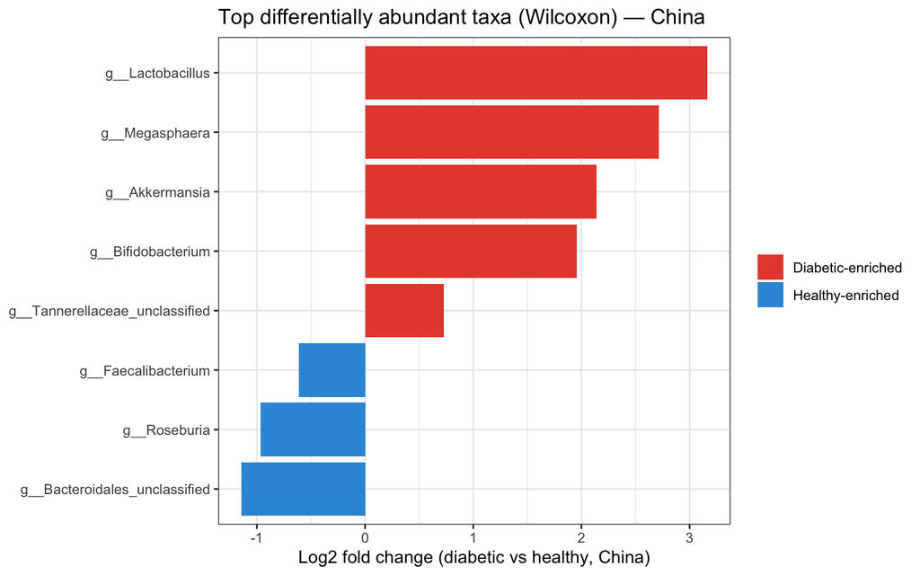

```r
# Top-taxa bar chart
bind_rows(
  wilcox_china %>% filter(q_value < 0.05) %>% arrange(-log2_fc) %>% head(10),
  wilcox_china %>% filter(q_value < 0.05) %>% arrange(log2_fc)  %>% head(10)
) %>%
  distinct() %>%
  mutate(direction = ifelse(log2_fc > 0, "Diabetic-enriched", "Healthy-enriched")) %>%
  ggplot(aes(x = reorder(Genus, log2_fc), y = log2_fc, fill = direction)) +
    geom_col() +
    coord_flip() +
    scale_fill_manual(values = c(
      "Diabetic-enriched" = "#E74C3C",
      "Healthy-enriched"  = "#3498DB"
    )) +
    labs(x = NULL,
         y = "Log2 fold change (diabetic vs healthy, China)",
         fill = NULL,
         title = "Top differentially abundant taxa (Wilcoxon) — China") +
    theme_bw()
```

## Compositional Analysis — CLR Linear Model

### Running CLR + GLM

```r
clr_china <- run_clr_lm(
  ps_clr      = china_t$clr,
  formula_str = "clr ~ sex + status + age + depth",
  term_filter = "statusD003924"
)


china_healthy_enriched <- clr_china %>%
  select(taxon, Genus, estimate, std.error, statistic, p.value, q_value) %>%
  arrange(estimate) %>%
  head(10)

china_sick_enriched <- clr_china %>%
  select(taxon, Genus, estimate, std.error, statistic, p.value, q_value) %>%
  arrange(-estimate) %>%
  head(10)

china_healthy_enriched
```

```
## # A tibble: 10 × 7
##    taxon  Genus                     estimate std.error statistic p.value q_value
##    <chr>  <chr>                        <dbl>     <dbl>     <dbl>   <dbl>   <dbl>
##  1 841    g__Roseburia                -3.92      0.993    -3.95  9.50e-5 0.00551
##  2 216851 g__Faecalibacterium         -2.97      0.896    -3.31  1.03e-3 0.0200
##  3 838    g__Bacteroidales_unclass…   -2.30      1.00     -2.29  2.24e-2 0.107
##  4 1730   g__Eubacterium              -1.79      1.00     -1.78  7.56e-2 0.292
##  5 724    g__Haemophilus              -1.26      0.524    -2.41  1.66e-2 0.107
##  6 33042  g__Coprococcus              -0.993     0.594    -1.67  9.54e-2 0.307
##  7 570    g__Klebsiella               -0.825     0.696    -1.19  2.36e-1 0.596
##  8 1263   g__Ruminococcus             -0.659     1.02     -0.644 5.20e-1 0.896
##  9 572511 g__Blautia                  -0.637     1.00     -0.636 5.25e-1 0.896
## 10 544    g__Citrobacter              -0.390     0.166    -2.35  1.96e-2 0.107
```

```r
china_sick_enriched
```

```
## # A tibble: 10 × 7
##    taxon  Genus                     estimate std.error statistic p.value q_value
##    <chr>  <chr>                        <dbl>     <dbl>     <dbl>   <dbl>   <dbl>
##  1 375288 g__Tannerellaceae_unclas…    2.64      0.950     2.78  5.75e-3  0.0667
##  2 906    g__Megasphaera               2.18      0.652     3.35  8.98e-4  0.0200
##  3 1578   g__Lactobacillus             1.45      0.514     2.83  4.98e-3  0.0667
##  4 239934 g__Akkermansia               1.34      0.547     2.45  1.47e-2  0.107
##  5 1678   g__Bifidobacterium           1.26      0.932     1.35  1.78e-1  0.517
##  6 397864 g__Barnesiellaceae_uncla…    1.16      0.500     2.32  2.11e-2  0.107
##  7 100883 g__Coprobacillus             1.05      0.416     2.54  1.17e-2  0.107
##  8 292632 g__Ruminococcaceae_uncla…    0.821     0.984     0.835 4.04e-1  0.782
##  9 848    g__Fusobacterium             0.722     0.600     1.20  2.30e-1  0.596
## 10 904    g__Acidaminococcus           0.710     0.396     1.79  7.36e-2  0.292
```

### Plots

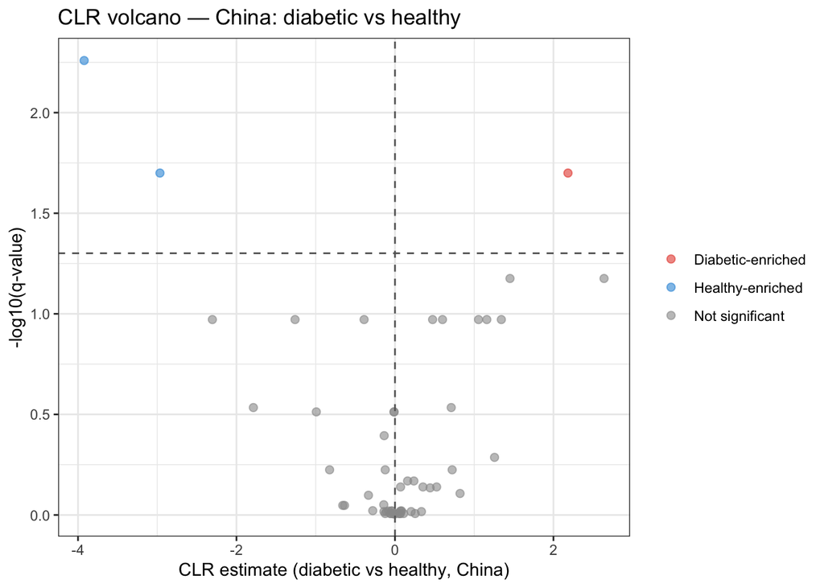

```r
plot_volcano(clr_china,
             x_label   = "CLR estimate (diabetic vs healthy, China)",
             title     = "CLR volcano — China: diabetic vs healthy",
             pos_label = "Diabetic-enriched",
             neg_label = "Healthy-enriched")
```

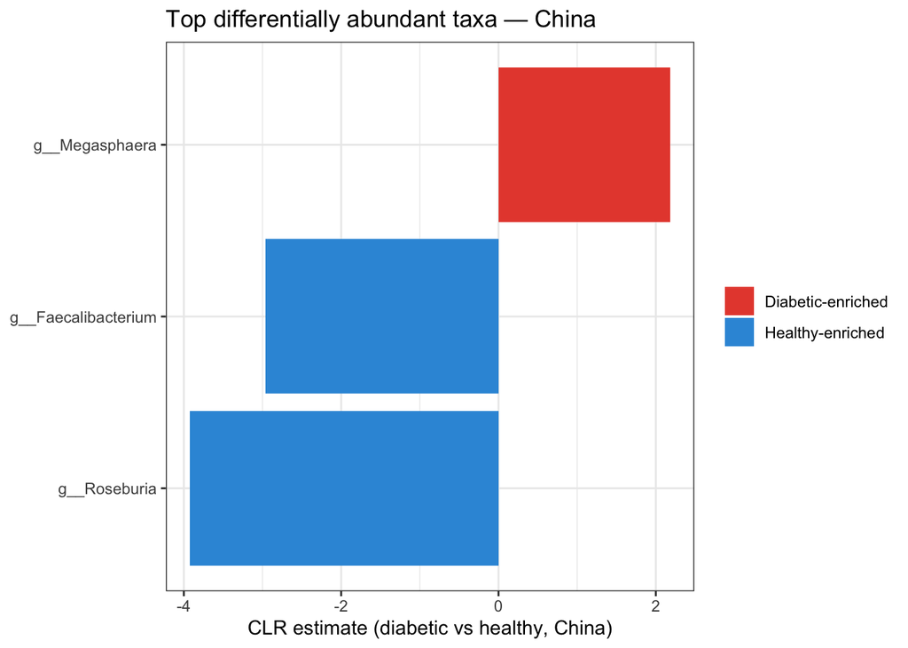

```r
plot_top_taxa(clr_china,
              x_label   = "CLR estimate (diabetic vs healthy, China)",
              title     = "Top differentially abundant taxa — China",
              pos_label = "Diabetic-enriched",
              neg_label = "Healthy-enriched")
```

### Wilcoxon vs CLR Comparison

```r
# Significant taxa summary
tibble(
  method        = c("Wilcoxon", "CLR"),
  n_significant = c(
    sum(wilcox_china$q_value < 0.05, na.rm = TRUE),
    sum(clr_china$q_value    < 0.05, na.rm = TRUE)
  )
)
```

```
## # A tibble: 2 × 2
##   method   n_significant
##   <chr>            <int>
## 1 Wilcoxon             8
## 2 CLR                  3
```

```r
# Consensus taxa significant in both methods
wilcox_china %>%
  select(taxon, Genus, wilcox_log2fc = log2_fc, wilcox_q = q_value) %>%
  inner_join(
    clr_china %>% select(taxon, clr_estimate = estimate, clr_q = q_value),
    by = "taxon"
  ) %>%
  filter(wilcox_q < 0.05, clr_q < 0.05) %>%
  mutate(direction_agreement = sign(wilcox_log2fc) == sign(clr_estimate)) %>%
  arrange(wilcox_q)
```

```
## # A tibble: 3 × 7
##   taxon  Genus   wilcox_log2fc wilcox_q clr_estimate   clr_q direction_agreement
##   <chr>  <chr>           <dbl>    <dbl>        <dbl>   <dbl> <lgl>
## 1 841    g__Ros…        -0.965 0.000186        -3.92 0.00551 TRUE
## 2 216851 g__Fae…        -0.610 0.00153         -2.97 0.0200  TRUE
## 3 906    g__Meg…         2.72  0.00159          2.18 0.0200  TRUE
```

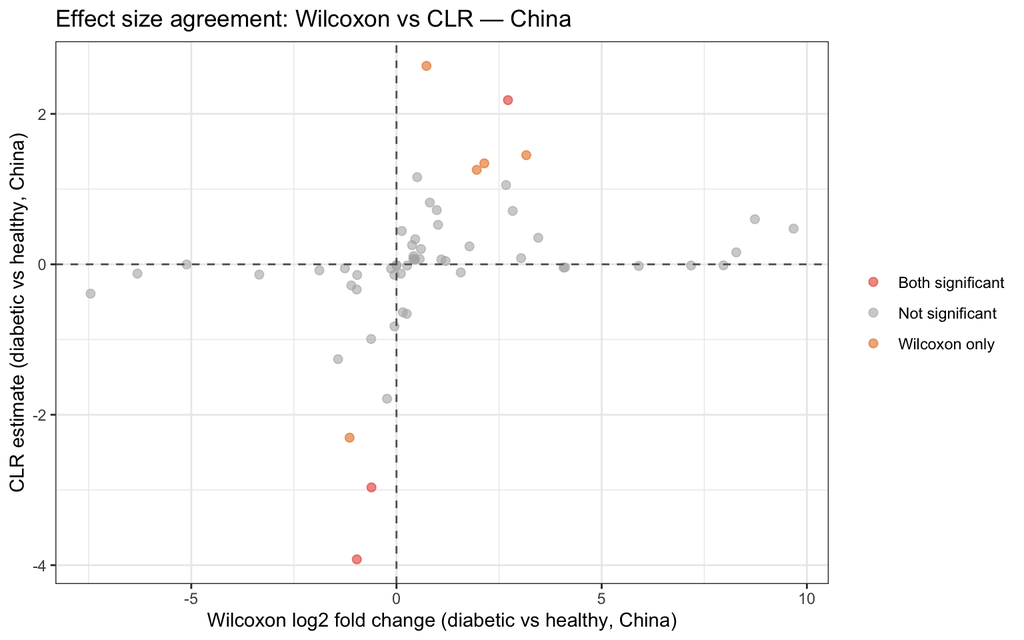

```r
# Cross-method effect size scatter
plot_wilcox_clr_comparison(
  wilcox_res    = wilcox_china,
  clr_res       = clr_china,
  wilcox_x_label = "Wilcoxon log2 fold change (diabetic vs healthy, China)",
  clr_y_label    = "CLR estimate (diabetic vs healthy, China)",
  title          = "Effect size agreement: Wilcoxon vs CLR — China"
)
```

## Constrained Ordination — RDA

Within China, the CLR matrix is constrained by disease status, sex, age, and sequencing depth (country is constant so it is omitted).

```r
rda_china_out <- run_rda(
  ps_clr      = china_t$clr,
  formula_str = "Disease.MESH.ID + Sex + as.numeric(Host.age) + as.numeric(Nr..reads.sequenced)",
  covariates  = c("Disease.MESH.ID", "Sex", "Host.age", "Nr..reads.sequenced")
)
```

```
## Samples removed due to NAs: 0
## Samples retained: 359
```

```r
anova(rda_china_out$rda, permutations = 999)
```

```
## Permutation test for rda under reduced model
## Permutation: free
## Number of permutations: 999
##
## Model: rda(formula = clr_clean ~ Disease.MESH.ID + Sex + as.numeric(Host.age) + as.numeric(Nr..reads.sequenced), data = meta_clean)
##           Df Variance    F Pr(>F)
## Model      4    31.81 2.02  0.001 ***
## Residual 354  1393.65
## ---
## Signif. codes:  0 '***' 0.001 '**' 0.01 '*' 0.05 '.' 0.1 ' ' 1
```

```r
anova(rda_china_out$rda, by = "term", permutations = 999)
```

```
## Permutation test for rda under reduced model
## Terms added sequentially (first to last)
## Permutation: free
## Number of permutations: 999
##
## Model: rda(formula = clr_clean ~ Disease.MESH.ID + Sex + as.numeric(Host.age) + as.numeric(Nr..reads.sequenced), data = meta_clean)
##                                  Df Variance      F Pr(>F)
## Disease.MESH.ID                   1    16.84 4.2784  0.001 ***
## Sex                               1     4.99 1.2671  0.189
## as.numeric(Host.age)              1     5.53 1.4053  0.118
## as.numeric(Nr..reads.sequenced)   1     4.45 1.1292  0.300
## Residual                        354  1393.65
## ---
## Signif. codes:  0 '***' 0.001 '**' 0.01 '*' 0.05 '.' 0.1 ' ' 1
```

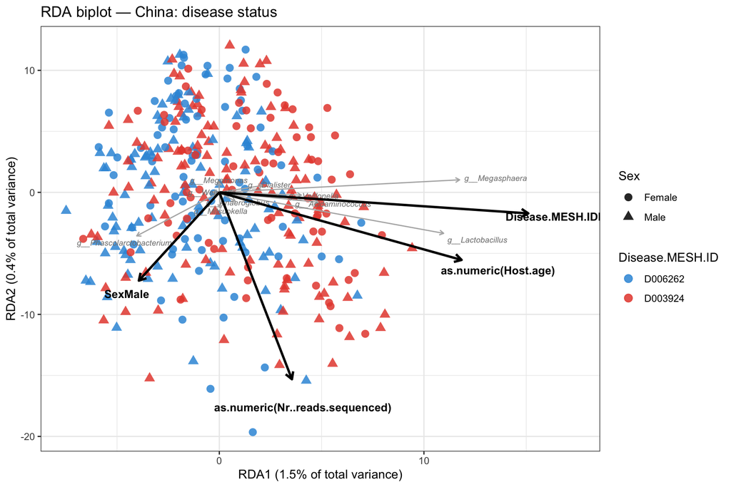

```r
plot_rda_biplot(
  rda_obj      = rda_china_out$rda,
  meta_df      = rda_china_out$meta,
  color_var    = "Disease.MESH.ID",
  shape_var    = "Sex",
  color_values = c("D003924" = "#E74C3C", "D006262" = "#3498DB"),
  shape_values = c("Female" = 16, "Male" = 17),
  title        = "RDA biplot — China: disease status"
)
```